# Básico de Métodos Computacionais

```python
import numpy as np
import matplotlib.pyplot as plt
import pandas as pd

from numba import jit  # colocando @jit acima de uma função, fará com que o python a tente otimizar (e correrá mais rápido), no fundo, isto é otimização para preguiçosos... mas pode ser útil...
import timeit  # podemos depois usar ``%timeit f(x)`` para retornar o tempo que demorou a correr a função f(x)

plt.style.use("seaborn")  # estilo que costumo usar para tornar gráficos "mais bonitos"
np.seterr(divide = 'ignore', invalid = 'ignore')  # usar isto pode ser útil em alguns casos
```

```
{'divide': 'warn', 'over': 'warn', 'under': 'ignore', 'invalid': 'warn'}
```

Se o computador já reconhece a linguagem (já existe um path), para adicionar uma biblioteca nova ao abrir o terminal e escrevendo `python -mpip install -U "nomes_das_bibliotecas"`. Raramente, uma biblioteca irá instalar completamente, mas não será possível usá-la. Nestes casos, devemos procurá-la no computador e movê-la para algum lado onde ela é reconhecida. Podemos saber esses lugares abrindo o python e escrevendo import sys e print(sys.path).

Se nós próprios quisermos criar uma biblioteca, se tivermos um ficheiro `exemplo.py` com a função `func()`, podemos executá-la noutro ficheiro se o colocarmos num lugar onde é reconhecido e se escrevermos, no novo ficheiro, `import exemplo`. Depois, basta escrever `exemplo.func()`. Se tivermos uma pasta chamada `graficamente`, num lugar onde o python a reconhece, podemos executá-la num novo ficheiro, escrevendo `import graficamente`. Porém, o python não lê tudo o que está dentro da pasta, só o ficheiro `__init__.py` (se não existir, não lê nada); logo, este deve importar todos os ficheiros e subpastas dentro da nossa pasta principal, fazendo algo como `from .exemplo import *` para cada.

# Importar Dados

```python
# data = np.loadtxt('./cpresources/sunspots.txt')  # loadtxt serve para carregar dados de um ficheiro txt escolhido

# mês,mancha_solar = data[:,0],data[:,1]
```

# Derivadas e Integrais

O valor de $h$ tem de ser o mais próximo de $0$ possível; porém, se for muito pequeno, devido à precisão do nº de casas decimais, existirá um ponto em que $f(x+h)−f(x)=0$ e o valor retomado é sempre $0$. Cada método tem também um erro associado - em projetos importantes, deve-se ter o erro em conta. É boa ideia testar como é que o nosso algorítmo $f(N)$ escala com $N$. Escrevemos isso da forma $f(N) \sim O(n^m)$. Como determinar isto? Se não o conseguimos fazer matematicamente, é testando. Aumenta o $N$, faz um gráfico e faz um fit. Deixando agora esse tema de lado, vejamos os algoritmos:

```python
def derivada(f, x):
    """Calcula o valor da derivada de f, no ponto x"""
    h = 10e-14
    return (f(x + h) - f(x)) / h


# Este método abaixo costuma ser mais preciso, em geral, podemos tentar fazer uma tabela de compração para vários h e verificar
def derivada_centrada(f, x):
    """Calcula o valor da derivada de f, no ponto x"""
    h = 10e-14
    return (f(x + (h / 2)) - f(x - (h / 2))) / h


def integral_trapezio(f, inicial, final):
    """Calcula o integral de f(x) pela regra do trapézio"""
    N = 1000
    h = (final - inicial) / N
    x = np.linspace(inicial, final, N + 1)
    f1 = f(x)
    return h * ((f1[0] + f1[-1]) / 2 + f1[1:-1].sum())


@jit  # EXEMPLO DE UTILIZAÇÃO DE @jit - vai simplificar/ajudar a correr a função abaixo
def integral_simpson(f, inicial, final):
    """Calcula o integral de f(x) por simpson 1/3"""
    N = 1000  # Para este integral, N tem de ser SEMPRE par!
    h = (final - inicial) / N
    x = np.linspace(inicial, final, N + 1)
    f1 = f(x)
    return h / 3 * (f1[0] + f1[-1] + 2 * f1[2:-2:2].sum() + 4 * f1[1:-1:2].sum())
```

# Propagação de Incertezas

```python
# Imports necessários se queremos trabalhar com isto
from scipy.optimize import curve_fit
from scipy.stats import linregress
```

```python
class MonteCarlo:

    def __init__(self, xdata, ydata, xerr=None, yerr=None):
        """o método __init__(), que se lê `dunder init` por estar entre underscores duplos, define, para cada objeto "self",
        um conjunto de atributos que, neste caso, são `xdata`, `ydata`, `data`, `N`, `xerr`, `yerr` e `r2`"""
        self.xdata = xdata
        self.ydata = ydata
        self.data = xdata, ydata
        self.N = len(self.xdata)

        if xerr is None:
            self.xerr = np.zeros(self.N)
        else:
            self.xerr = xerr

        if yerr is None:
            self.yerr = np.zeros(self.N)
        else:
            self.yerr = yerr

        slope, intercept, r_value, p_value, std_err = linregress(self.xdata, self.ydata)  # calcula o valor de r
        self.r2 = r_value**2

    # NOTA: se o método só dependesse de `self` podiamos colocar aqui `@property` e este passaria a comportar-se como atributo, não necessitando de parentesis ao ser chamado
    def geral(self, f, iteracoes=500, p0=None, maxfev=400):
        """Aplicar simulação de Monte Carlo a uma função f(x) qualquer definida por nós"""

        # Fazer um ajuste sem ter em conta as incertezas nas medidas de 'x' e 'y'
        par = curve_fit(f, *self.data, p0=p0, maxfev=maxfev)[0]  # nota: se colocar "bounds", o nome do parâmetro maxfev passa a ser: max_nfev...
        Npar = len(par)

        # Gerar distribuição normal, localizada em cada uma das medidas, com base nas incertezas
        err = np.zeros((iteracoes + 1, Npar))
        for i in range(iteracoes):
            x_new = self.xdata + (self.xerr * np.random.normal(loc=0, size=self.N))
            y_new = self.ydata + (self.yerr * np.random.normal(loc=0, size=self.N))
            # Estimar parâmetros (repetir o mesmo ajuste) para o novo conjunto de pontos
            par_new = curve_fit(f, x_new, y_new, p0=p0, maxfev=maxfev)[0]
            err[i] = par_new

        # Calcular o desvio padrão dos parâmetros
        for i in range(Npar):
            err[iteracoes, i] = np.std(err[:iteracoes, i])

        return par, err[iteracoes]

    def poly(self, grau, iteracoes=500):
        """Aplicar simulação de Monte Carlo a uma função polinomial de grau N, sendo somente necessário definir o valor de N"""

        # Fazer um ajuste sem ter em conta as incertezas nas medidas de 'x' e 'y'
        par = np.polyfit(*self.data, grau)
        Npar = len(par)

        # Gerar distribuição normal, localizada em cada uma das medidas, com base nas incertezas
        err = np.zeros((iteracoes + 1, Npar))
        for i in range(iteracoes):
            x_new = self.xdata + (self.xerr * np.random.normal(loc=0, size=self.N))
            y_new = self.ydata + (self.yerr * np.random.normal(loc=0, size=self.N))
            # Estimar parâmetros (repetir o mesmo ajuste) para o novo conjunto de pontos
            par_new = np.polyfit(x_new, y_new, grau)
            err[i] = par_new

        # Calcular o desvio padrão dos parâmetros
        for i in range(Npar):
            err[iteracoes, i] = np.std(err[:iteracoes, i])

        return par, err[iteracoes]
```

Antes de avançar, vamos aqui fazer algumas notas sobre classes...

É possível mudar atributos fora da classe. Fazendo `MonteCarlo.xdata = 1` estaremos a definir `self.xdata = 1` para a classe. Também podemos fazer `exemplo.xdata = 1` (sendo `exemplo` uma instância de `MonteCarlo`) para alterar o atributo desse objeto.

Fazendo `exemplo.__dict__`, obtemos informação deste objeto sob a forma de dicionário.

Para além de `@property`, também temos `@classmethod` (métodos com isto em cima afetam toda a classe e não só a instância e, como padrão, em vez de escrever `self` no argumento da função, escrevemos `cls`) e `@staticmethod` (métodos com isto em cima não precisam de `self` ou `cls`, mas podem ter outros argumentos, pois não alteram nada na instância ou na classe - ex: apenas estão a dar print a alguma coisa).

Existem outros "dunder" com que podemos trabalhar. Por exemplo, podemos definir os métodos `__add__` ou `__mul__` para definir o que acontece quando tentamos adicionar ou multiplicar duas instâncias pertencentes à classe, respetivamente (existem muitos outros **python special method names** que podemos usar).

Por último, pode ser útil definir subclasses, se quisermos usar parte dos métodos da classe principal. Pesquisa como isto se faz, caso necessites...

```python
def derivada(f, indice_da_variavel, pontos):
    """Calcula a derivada parcial de f(x0,...,xn), em relação a xi, nos pontos np.array([])..."""
    h = 10e-14

    pontosH = np.copy(pontos)
    # podiamos fazer (f(x + h) - f(x)) / h; porém, vamos fazer derivada centrada, somando h/2 a "pontosH" e substraindo h/2 a "pontos"
    pontosH[indice_da_variavel] += h / 2
    pontos[indice_da_variavel] -= h / 2

    return (f(*pontosH) - f(*pontos)) / h

def incerteza(f, pontos, incertezas):
    """Propagação de incertezas da função f(x0,...,xn) avaliada nos pontos np.array([...]), com as incertezas np.array([...]),
    estando a considerar covariância nula. IMPORTANTE: OS ARRAYS TÊM DE ESTAR COMO FLOATS..."""
    incerteza2 = 0  # quadrado da incerteza de f

    for i in range(len(pontos)):
        parcial = derivada(f, i, pontos)
        incerteza2 += (parcial * incertezas[i])**2

    return np.sqrt(incerteza2)
```

# Transformada de Fourier

Estando a trabalhar com computadores, existem somente sinais digitais (discretos). Sendo assim, todas as transformadas que vamos obter serão periódicas, sendo que $X_{k+N}=X_k$. Ok, mas isto só nos fala dos índices $\omega[k]$, quais os valores de $\omega$ com que estamos a trabalhar? As TF são periódicas de período $2 \pi$, sendo a parte real par e a parte imaginária ímpar (para input real). Temos então a Forward Discrete Fourier Transform (DFT): $$ X_k = \sum_{n=0}^{N-1} x_n e^{-i 2 \pi k n /N}. $$

Inverse Discrete Fourier Transform (IDFT): $$ x_n = \frac{1}{N} \sum_{k=0}^{N-1} X_k e^{ i 2 \pi k n /N}. $$

Note-se que o python não costuma fazer esta divisão por $N$ automaticamente, temos de ser nós a fazer. Que outras coisas devemos ter em mente? É bom trabalhar em potencias de $2$ e a pior coisa que se pode fazer é trabalhar em loops - tendo a possibilidade de fazer operações ao mesmo tempo, devo deixar os loops de lado e fazer assim mesmo, por exemplo, usando matrizes ou arrays: $$ \overrightarrow{X} =M \cdot \overrightarrow{x}, $$ em que a matriz $ M$ é dada por $$ M_{kn} = e^{-i 2 \pi k n /N}. $$

Temos dois métodos de fazer isto: calculando diretamente ou fazendo uso de simetrias, usando algo chamado "fast fourier transform". Enquanto que a primeira cresce como $O(N^2)$, a FFT cresce como $O(N \log N)$.

```python
def dft(y, inversa=0):
    """Aplica a transformada de Fourier discreta, em 1D, ao array y.
    Atribuindo inversa=1, calcula a transformada inversa."""
    N = len(y)
    n = np.arange(N)  # vetor linha de 0 a N
    k = np.arange(N)[:, np.newaxis]  # vetor coluna de 0 a N
    M = np.exp(-2j * np.pi * (-1)**inversa * k * n / N)
    return np.dot(M, y)

def fft(y, inversa=0):
    """Aplica recursivamente a fast fourier transform ao array y, em 1D, com o algoritmo Cooley-Tukey.
    Atribuindo inversa=1, calcula a transformada inversa."""
    N = len(y)
    if N%2 > 0:
        raise ValueError("O tamanho do array deve ser uma potência de 2")
    elif N <= 32:
        return dft(y, inversa)  # não vale a pena aplicar fft a tão pequeno
    else:
        even = fft(y[::2], inversa)  # aplicação da fft aos termos pares
        odd = fft(y[1::2], inversa)  # aplicação da fft aos termos ímpares

        factor = np.exp(-2j * np.pi * (-1)**inversa * np.arange(N) / N)

        return np.concatenate([even + factor[:N // 2] * odd, even + factor[N // 2:] * odd])

def fft_vetorizada(y, inversa=0):
    """Versão vetorizada da fast fourier transform ao array y, em 1D, com o algoritmo Cooley-Tukey.
    Atribuindo inversa=1, calcula a transformada inversa."""
    N = len(y)

    if N%2 > 0:
        raise ValueError("O tamanho do array deve ser uma potência de 2")

    # Fará uma DFT de O(N^2) em todos os sub-problemas de tamanho N_min de uma só vez
    N_min = min(N, 32)
    Y = dft(y.reshape((N_min, -1)), inversa)

    # Constrói cada nível do cálculo recursivo de uma só vez
    while Y.shape[0] < N:
        even = Y[:, :Y.shape[1] // 2]
        odd = Y[:, Y.shape[1] // 2:]

        factor = np.exp(-1j * np.pi * (-1)**inversa * np.arange(Y.shape[0]) / Y.shape[0])[:, None]

        Y = np.vstack([even + factor * odd, even - factor * odd])

    return Y.ravel()
```

É necessário ter atenção à frequência de Nyquist; porém, não é necessário usar sempre $\geq 2f$ (nota: por vezesm ao aplicar Nyquist, vemos que é necessário bem mais que $2f$, principalmente ao trabalhar com frequências não inteiras - pelo menos deve ser necessário $\geq Nf$ inteiro). Porquê? Por exemplo, ao analisar uma pessoa a falar, podemos usar uma frequência de amostragem menor, pois as frequências mais altas não são assim tão necessárias (só crianças é que conseguem ouvir até aos $20000Hz$ e à medida que se envelhece, a capacidade de audição diminui, sendo que muitos adultos só ouvem abaixo de $15000Hz$).

Agora vamos falar de como podemos representar a transformada de Fourier (TF) e que informação somos capazes de obter. O input e output são discretos; logo, a única forma de conservarmos isto é considerar sempre as funções, no domínio do tempo, como discretas e periódicas. Se quisermos analisar uma função não-periódica, temos de a considerar como sendo periódica (infelizmente), mas podemos tentar fazer uma enorme taxa de amostragem, de forma a que a passagem entre os extremos direito e esquerdo seja brusca só no ponto de descontinuidade (e não esteja a estragar os pontos na função que queremos realmente tratar). Mas agora e se quisermos analisar uma função contínua (que é o que normalmente queremos fazer em problemas físicos)?

Para uma função contínua e periódica, a TF será discreta e não-periódica. Quanto a esta não-periodicidade da TF, não é difícil obter. Aquilo que conseguimos da nossa função `fft` já é apenas só um periodo; logo, se "mentirmos" no eixo dos $xx$, podemos representar a TF de uma função contínua e periódica. Sendo assim, podemos usar a função `np.fft.fftfreq` para obter o domínio de frequências $f$ (não estamos a trabalhar com a frequência angular $\omega$, mas sim com $f$, que é mais fácil de interpretar em alguns problemas físicos). É preciso ter isto em conta se quisermos fazer a derivada $f'(t) = i \omega F(\omega)$, pelo que neste caso temos de multiplicar as frequências por $2 \pi$, já que $\omega = 2 \pi f$.

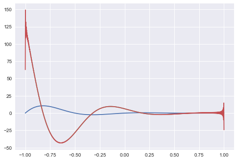

```python
def f(t):
    return np.sin(2*np.pi*t)*np.exp(-3*t)  # é preciso aumentar w para ter um melhor resultado (se for w=1, não dava bem)...

def f_prime(t):
    return (2*np.pi*np.cos(2*np.pi*t)-3*np.sin(2*np.pi*t))*np.exp(-3*t)

t = np.linspace(-1, 1, 2**10)
w = 2*np.pi*np.fft.fftfreq(len(t), d=t[1]-t[0])

f_prime_fourier = np.fft.ifft(1j*w*np.fft.fft(f(t)))

plt.plot(t, f(t))
plt.plot(t, f_prime(t))
plt.plot(t, f_prime_fourier)
```

Por último, quanto à função $F(\omega)$, as amplitudes que nos são retornadas não são as "corretas", tendo nós de fazer $\mathrm{magnitude}(z) = \frac{\sqrt{z.\mathrm{real}^2 + z.\mathrm{imag}^2}}{N}$ (para todos os valores $z$ da transformada) se quisermos saber a amplitude de cada frequência. Porém, **nunca usar a magnitude nos cálculos de transformadas** - em cálculos, como é óbvio, temos é de usar o resultado $F(\omega)$ obtido do algorítmo.

# Runge-kutta (Resolver ODE's)

```python
def rk(f, t, x0):
    """
    Aplica o método de Runge-Kutta de ordem 4 para encontrar a solução do PVI, sendo x0 a condição inicial.
    Irá retomar um array onde cada elemento corresponde à solução para o instante de tempo correspondente.
    """
    N = len(t)
    h = (max(t) - min(t)) / N

    x = np.zeros(N)

    for i in range(N):
        x[i] = x0
        k1 = h * f(x0, t[i])
        k2 = h * f(x0 + 0.5 * k1, t[i] + 0.5 * h)
        k3 = h * f(x0 + 0.5 * k2, t[i] + 0.5 * h)
        k4 = h * f(x0 + k3, t[i] + h)
        x0 += (k1 + 2 * k2 + 2 * k3 + k4) / 6

    return x
```

```python
def rk_geral(f, t, m0):
    """
    Aplica o método de Runge-Kutta de ordem 4 (generalizado para mais equações) para encontrar a solução do PVI, sendo m0 as condições iniciais.
    Irá retomar uma matriz, onde cada elemento da coluna i corresponde à solução (da variável i) para o instante de tempo correspondente.
    """
    N = len(t)
    h = (max(t) - min(t)) / N
    N0 = len(m0)

    m = np.zeros((N, N0))

    for i in range(N):
        m[i] = m0
        k1 = h * f(m0, t[i])
        k2 = h * f(m0 + 0.5 * k1, t[i] + 0.5 * h)
        k3 = h * f(m0 + 0.5 * k2, t[i] + 0.5 * h)
        k4 = h * f(m0 + k3, t[i] + h)
        m0 += (k1 + 2 * k2 + 2 * k3 + k4) / 6

    return m
```

**Nota 1**: as condições iniciais $x_0$ ou $m_0$ têm de estar sob a forma de float, caso contrário, o python irá constantemente arredondar por defeito em cada iteração; ex: m0=np.array([1.0, 2.0]).

**Nota 2**: a função deve ser definida da seguinte forma: $def$ $f(r, t):$ $return$ $np.array([r[1], 4 * (1 - r[0]**2) - r[0]], float)$.

Para ir buscar os valores, temos de escrever, por exemplo: r[:, 1] (os valores estão nas colunas).

# Equações Diferenciais Parciais

Existem vários tipos de PDE's. Equações elípticas (Poisson), parabólicas (calor) e hiperbólicas (onda), por exemplo. Quando nos referimos à equação de Poisson, escrita como $\nabla^2 u = k \cdot \rho(\overrightarrow{r})$, chamamos ao termo do lado direito "termo fonte". Na equação de calor, onde temos $\nabla^2 u = \frac{1}{k} \frac{\partial u}{\partial t}$, temos é o "termo de difusão". A parte complicada costuma andar à volta de como incluir estes termos...

O **método de Gauss-Seidel** é um método para resolver $\displaystyle{\frac{\partial^2\Phi}{\partial x^2} + \frac{\partial^2\Phi}{\partial y^2}} = 0$. Temos a condição fronteira que o potencial $\Phi$ cai para zero quando $r \rightarrow +\infty$. Usamos dois conceitos fundamentais: a solução é única; o valor do potencial num ponto $r_0$ vai ser igual à média dos valores que estão em seu redor.

Quanto à análise das condições fronteira, temos os seguintes casos:

- condições de Dirichlet: potencial fixo na fronteira (ex: condutor na fornteira, com dado valor);
- condições de Neumann: não é o potencial, mas sim a derivada que está bem definida na fronteira (ex: isolador na fronteira, que tem fluxo nulo);
- condições de Robin: condição mista, na forma $\alpha_l u(x,y)+ \beta_l \frac{\partial u(x,y)}{\partial (x)} = \gamma_l (y)$.

Em forma discreta, sendo o nosso espaço uma grelha discreta de dimensões $\Delta x$ e $\Delta y$ (e vamos impor a condição $\Delta x = \Delta y$), podemos chegar a uma expressão para $u^n_{i,j}$, para a *n-ésima* iteração (quantas mais iterações, mais próximo estará do valor real). O código está implementado abaixo (a razão porque não usamos matrizes é porque estas são esparsas - a maior parte da matriz é composta por zeros).

```python
@jit
def gauss_seidel(grelha, w):
    M = len(grelha[0])
    phi = np.copy(grelha)

    target = 1e-6  # precisão desejada
    delta = 1  # considerar este valor, somente para podermos entrar no ciclo while
    while delta>target:
        delta = 0

        for i in range(1, M-1):
            for j in range(1, M-1):
                if (i==20 and j<=80 and j>=20) or (i==80 and j<=80 and j>=20):
                    pass  # este comando tem o objetivo de manter as condições fronteira (para os pontos da grid definidos, nada será calculado)
                else:
                    difference = (phi[i+1,j] + phi[i-1,j] + phi[i,j+1] + phi[i,j-1])/4 - phi[i,j]

                    phi[i,j] = phi[i,j] + (1+w)*difference

                    if difference>delta:
                        delta = difference
    return phi
```

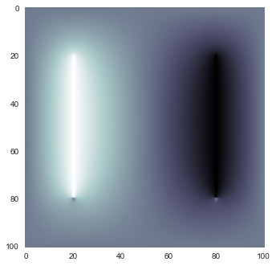

```python
phi = np.zeros([101,101],float)
phi[20, 20:80] = 1
phi[80, 20:80] = -1

p=gauss_seidel(phi, .9)

plt.imshow(p.T)
plt.grid(False)
plt.bone()
```

O método de Jacobi também é importante. O Gauss-Seidel é melhor, mas só porque sim, vamos ver como é o Jacobi e vamos ver como se aplica o termo fonte $f$:

```python
def Poisson2D_Jacobi_vec(u_antigo, f, dx, dy, iterar=1024):
    u = np.copy(u_antigo)
    for it in range(iterar):            # número fixo de iterações

        ud = u.copy()

        u[1:-1,1:-1] = (((ud[1:-1, 2:] + ud[1:-1, :-2]) * dy**2 +   # vectorizado (melhor que loops "for" nos nodos)
                    (ud[2:, 1:-1] + ud[:-2, 1:-1]) * dx**2 -
                    f[1:-1, 1:-1] * dx**2 * dy**2) /
                    (2 * (dx**2 + dy**2)))

    return u
```

Não vamos analisar outros métodos para não sobrecarregar estes resumos (podemos só ainda dizer que **Crank-Nicolson** é um excelente método para a eq. difusão), mas devemos ter em mente que aquilo que estamos aqui a mostrar neste ficheiro não é quase nada.

# Eliminação de Gauss

Estar sempre atento ao facto de que **matrizes são mutáveis** e podem ser alteradas dentro de uma função (o conceito de variável global vs. variável local não se aplica a matrizes). Ou seja, ou fazemos np.copy() da matriz quando a chamarmos dentro de uma função, ou ela será transformada.

```python
A = np.array([[0, 1, 4, 1],
              [3, 4, -1, -1],
              [1, -4, 1, 5],
              [2, -2, 1, 3]], float)
V = np.array([-4, 3, 9, 7], float)

AM = np.matrix(A.copy())
VM = np.matrix(V.copy()).transpose()
```

```python
def gauss_elim(matriz, sol):
    N = len(sol)

    for i in range(N):
        # Dividir a linha pelo elemento diagonal, para que este tome o valor 1
        div = matriz[i, i]
        matriz[i, i:] /= div  # todos os termos matriz[i, :i] serão 0 em qualquer iteração
        sol[i] /= div

        # Como o termo da diagonal é agora 1, vamos fazer os termos abaixo igual a zero, multiplicando a linha i pelo valor do i-termo de cada linha abaixo e subtraindo à linha toda
        mult = matriz[i + 1:, i]  # i-termo das linhas abaixo
        sol[i + 1:] -= mult * sol[i]

        for j in range(i + 1, N):
            matriz[j, i:] -= mult[j - i - 1] * matriz[i, i:]

    # Backsubstitution
    x = np.empty(N, float)
    for i in range(N - 1, -1, -1):
        x[i] = sol[i] - np.dot(matriz[i, i + 1:], x[i + 1:])

    return x


def gauss_pivot(matriz, sol):
    """
    Irá aplicar a eliminação de Gauss com pivotagem parcial
    """
    N = len(sol)

    for i in range(N):
        # Pivotagem
        for j in range(i + 1, N):
            if matriz[i, i] < matriz[j, i]:
                matriz[[i, j], :] = matriz[[j, i], :]
                sol[[i, j]] = sol[[j, i]]

        # Dividir a linha pelo elemento diagonal, para que este tome o valor 1
        div = matriz[i, i]
        matriz[i, i:] /= div  # todos os termos matriz[i, :i] serão 0 em qualquer iteração
        sol[i] /= div

        # Como o termo da diagonal é agora 1, vamos fazer os termos abaixo igual a zero, multiplicando a linha i pelo valor do i-termo de cada linha abaixo e subtraindo à linha toda
        mult = matriz[i + 1:, i]  # i-termo das linhas abaixo
        sol[i + 1:] -= mult * sol[i]

        for j in range(i + 1, N):
            matriz[j, i:] -= mult[j - i - 1] * matriz[i, i:]

    # Backsubstitution
    x = np.empty(N, float)
    for i in range(N - 1, -1, -1):
        x[i] = sol[i] - np.dot(matriz[i, i + 1:], x[i + 1:])

    return x
```

# Decomposição QR e Valores/Vetores próprios

Os vetores próprios podem não ser os mesmos que resultam de funções como `np.linalg`, as é importante lembrar: vetores colineares a vetores próprios **são também vetores próprios**.

```python
def QR(A):
    """
    Introduzindo uma matriz, a função fará a sua decomposição QR
    """
    N = len(A[0])

    u = np.zeros([N, N])  # criar matriz de vetores ui
    q = np.zeros([N, N])  # criar matriz de vetores qi, o que equivale à matriz Q
    r = np.zeros([N, N])  # criar matriz R

    # Calcular valores de 'ui' e de 'qi'
    for i in range(N):

        soma = np.zeros(N)  # soma de vetores que será depois subtraido ao vetor ai

        for j in range(i):
            soma += np.dot(q[:, j], A[:, i]) * q[:, j]

        ui = A[:, i] - soma
        qi = ui / np.sqrt(sum(ui**2))

        u[:, i] = ui  # adicionar vetor à matriz u
        q[:, i] = qi  # adicionar vetor à matriz Q

    # Preencher a matriz R
    for i in range(N):

        for j in range(0, i):
            r[j, i] = np.dot(q[:, j], A[:, i])

        r[i, i] = np.sqrt(sum(u[:, i]**2))

    return q, r


def eigen(A):
    """
    Introduzindo uma matriz, a função irá retomar os seus valores próprios e vetores próprios
    """
    N = len(A[0])
    V = np.identity(N)

    err = 1
    while err >= 1e-6:
        Q, R = QR(A)
        A = np.dot(R, Q)
        V = np.dot(V, Q)
        err = np.max(abs(A - np.identity(N) * A))

    return np.diag(A), V
```

# Encontrar Zeros de $f(x)$

O **método de Newton** é bastante rápido, mas implica saber a derivada de $f$ analiticamente. Para resolver a nossa equação, temos sempre de começar por escrevê-la como $f(x)=0$, obtendo esta função $f(x)$ com que vamos trabalhar. Se $f(x)$ for um polinómio (ou outra coisa assim tão fácil de derivar), é sempre este o método que temos de usar! Se não soubermos a derivada analiticamente, temos de a estimar com o python - a isso já não chamamos método de newton, mas sim: método da secante.

definimos também o vetor de previsões, sob a forma de matriz, ex: vec=np.matrix([[1], [2]], float). Para várias variáveis, não conseguimos calcular o erro facilmente, aquilo que definimos então, é o número de iterações N.

```python
def newton(x, f, f1, f2):
    """Aplica o método de newton à nossa previsão x do zero, sendo fn a n-ésima derivada de f"""
    err = abs(f(x) / f1(x))  # aceitando o erro inicial como a diferença x(i+1)-x(i)
    while err >= 1e-10:
        err = err**2 * .5 * abs(f2(x) / f1(x))
        x -= f(x) / f1(x)
    return x


def newton_mult(vec, F, J, N):
    """Aplica o método de newton para duas variáveis
    (para mais variáveis, é só corrigir um pouco a função que nos dá o novo 'vec')"""
    for i in range(N):
        vec -= np.dot(np.linalg.inv(J(vec[0, 0], vec[1, 0])), F(vec[0, 0], vec[1, 0]))
    return vec
```

```python
gr = (1 + np.sqrt(5)) / 2  # golden ratio

def ouro(x1, x4, f):
    """Calcula o mínimo de um intervalo [x1, x4] usando o método da regra de ouro"""
    x2 = x4 - (x4 - x1) / gr
    x3 = x1 + (x4 - x1) / gr

    while abs(x2 - x3) >= 1e-6:
        if f(x2) < f(x3):
            x4 = x3
        else:
            x1 = x2

        x2 = x4 - (x4 - x1) / gr
        x3 = x1 + (x4 - x1) / gr

    return (x1 + x4) / 2
```